```python
from IPython.display import Image
import numpy as np
```

```python
import importlib
class Aviv_Simplicity:
    """
    A class used for simplicity.
    Input:
        product: a datacube ingested product name string.
            use:
            dc = datacube.Datacube(app    = "my_random_app",
                       config = "/home/localuser/.datacube.conf")
            dc.list_products()

        to see all the available products

        utils_foler: The directory that has the data_access_api.py this is usually in datacube_notebooks

        config file: The datacube configuration file


    """
    def __init__(self,product, utils_folder ='/home/local/AMA-INC/amelbag/aviv_notebook_server/GANs/scpd/data_cube_utilities/data_access_api.py',config_file = "/home/localuser/.datacube.conf" ):
        self.product= product
        print(self.product)
        loader = importlib.machinery.SourceFileLoader('utils', utils_folder)
        handle = loader.load_module('utils')
        self.api = handle.DataAccessApi(config=config_file)
        self.meta_data = self.api.get_datacube_metadata(product = self.product)
        self.dc = datacube.Datacube(app    = "my_random_app",
                       config = "/home/localuser/.datacube.conf")


    def show_extents(self,MAPPING = True):
        import folium
        """
        Shows all available extents of the specified product"""
        lats = self.meta_data['lat_extents']
        lons =self.meta_data['lon_extents']
        times = self.meta_data['time_extents']
        print("For: ", str(self.product))
        print('The latitude extents are ' + str(lats))
        print('The longitude extents are ' + str(lons))
        print('The time extents are ' + str(times))

        #returns the map as well
        if MAPPING == True:
            mapa = folium.Map([np.mean(lats), np.mean(lons)], zoom_start=13,tiles='Stamen Terrain')
            mapa.fit_bounds([[lats[0],lons[0]],[lats[1],lons[1]]])
            folium.Marker([lats[0],lons[0]]).add_to(mapa)
            folium.Marker([lats[0],lons[1]]).add_to(mapa)
            folium.Marker([lats[1],lons[0]]).add_to(mapa)
            folium.Marker([lats[1],lons[1]]).add_to(mapa)
            return [lats,lons,times, mapa]

        #Else don't return the map
        return [lats,lons,times]

#     def get_extent(lats,lons):
#         self.dc.load_data()
```

# Localized Linear Histogram Match(LLHM)

Based off the paper: SLC Gap-Filled Products Phase One Methodology by Scaramuzza et al

In May 2003 the Scan Line Corrector on the Landsat 7 failed. The Scan line corrector is responsible for compensating for the forward motion of the sattelite. Without the compensator you are left with the black bands which comprise around 22% of all the LS7 data. There are many ways to fill these gaps. In this series we will explain the various methods.

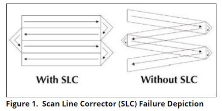

```python
Image('SLCGAP.JPG')
```

## Number 1 in the SLC Band Gap Filling Series

## Before we start let's show an example:

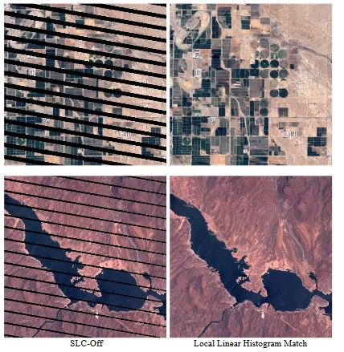

```python
Image('First.JPG')
```

### This method is the simplest of all methods. And requires a scene from prior to the failure in 2003.

$$Y\approx GX+B$$

$\text{where: } \\ G = \frac{\sigma_y}{\sigma_x} \\ B = \bar{Y} - G \bar{X} \\ $

$ \sigma_x = \text{the standard deviation of data in SLC-on image X.} \\ \sigma_y = \text{the standard deviation of data in SLC-off image Y.} \\ \bar{X} = \text{The mean of the SLC-On scene array} \\ \bar{Y} = \text{The mean of the SLC-Off scene array} $

One thing to note is that you don't use the pixels that are not known in the calculation of the variables.

## Using Datacube we need to see the data that we want.

```python
import datacube as datacube
import matplotlib.pyplot as plt
```

```python
dc = datacube.Datacube(app    = "my_random_app",
                       config = "/home/localuser/.datacube.conf")
dc.list_products()
```

| id | name | description | time | lat | instrument | product_type | format | platform | lon | crs | resolution | tile_size | spatial_dimensions |
| --- | --- | --- | --- | --- | --- | --- | --- | --- | --- | --- | --- | --- | --- |
| 46 | alos2_jjfast_scansar_tile | ALOS-2 PALSAR JJ-FAST mosaic tiles generated f... | None | None | PALSAR | tile | GeoTiff | ALOS_2 | None | NaN | NaN | NaN | NaN |
| 61 | alos2_jjfast_scansar_tile_colombia | ALOS2 PALSAR JJFAST tile in DN format processe... | None | None | PALSAR | tile | NetCDF | ALOS_2 | None | EPSG:4326 | [-0.0002666666667, 0.0002666666667] | [0.5333333334, 0.5333333334] | (latitude, longitude) |
| 64 | alos2_palsar2_scansar | ALOS-2 PALSAR JJ-FAST mosaic tiles generated f... | None | None | PALSAR_2 | tile | GeoTiff | ALOS_2 | None | NaN | NaN | NaN | NaN |
| 65 | alos2_palsar2_scansar_caqueta | ALOS2 PALSAR JJFAST tile in DN format processe... | None | None | PALSAR_2 | tile | NetCDF | ALOS_2 | None | EPSG:4326 | [-0.0002666666667, 0.0002666666667] | [0.5333333334, 0.5333333334] | (latitude, longitude) |
| 50 | alos2_palsar_colombia | ALOS2 PALSAR tile in DN format processed for t... | None | None | PALSAR | gamma0 | NetCDF | ALOS_2 | None | EPSG:4326 | [-0.0002666666667, 0.0002666666667] | [0.5333333334, 0.5333333334] | (latitude, longitude) |
| 51 | alos2_palsar_kenya | ALOS2 PALSAR tile in DN format processed for t... | None | None | PALSAR | gamma0 | NetCDF | ALOS_2 | None | EPSG:4326 | [-0.0002666666667, 0.0002666666667] | [0.5333333334, 0.5333333334] | (latitude, longitude) |
| 48 | alos2_palsar_tile | ALOS-2 PALSAR mosaic tiles generated for use i... | None | None | PALSAR | gamma0 | GeoTiff | ALOS_2 | None | NaN | NaN | NaN | NaN |
| 52 | alos2_palsar_vietnam | ALOS2 PALSAR tile in DN format processed for t... | None | None | PALSAR | gamma0 | NetCDF | ALOS_2 | None | EPSG:4326 | [-0.0002666666667, 0.0002666666667] | [0.5333333334, 0.5333333334] | (latitude, longitude) |
| 53 | alos_palsar_colombia | ALOS PALSAR tile in DN format processed for th... | None | None | PALSAR | gamma0 | NetCDF | ALOS | None | EPSG:4326 | [-0.0002666666667, 0.0002666666667] | [0.5333333334, 0.5333333334] | (latitude, longitude) |
| 54 | alos_palsar_kenya | ALOS PALSAR tile in DN format processed for th... | None | None | PALSAR | gamma0 | NetCDF | ALOS | None | EPSG:4326 | [-0.0002666666667, 0.0002666666667] | [0.5333333334, 0.5333333334] | (latitude, longitude) |
| 47 | alos_palsar_tile | ALOS PALSAR mosaic tiles generated for use in ... | None | None | PALSAR | gamma0 | GeoTiff | ALOS | None | NaN | NaN | NaN | NaN |
| 55 | alos_palsar_vietnam | ALOS PALSAR tile in DN format processed for th... | None | None | PALSAR | gamma0 | NetCDF | ALOS | None | EPSG:4326 | [-0.0002666666667, 0.0002666666667] | [0.5333333334, 0.5333333334] | (latitude, longitude) |
| 5 | gpm_imerg_gis_daily | GIS translation of the imerg data product. Mul... | None | None | GPM | daily | GeoTiff | GPM | None | NaN | NaN | NaN | NaN |
| 14 | gpm_imerg_gis_daily_global | Global NetCDF GPM IMERG GIS data | None | None | GPM | daily | NetCDF | GPM | None | EPSG:4326 | [-0.1, 0.1] | [90, 180] | (latitude, longitude) |
| 6 | gpm_imerg_gis_hourly | GIS translation of the imerg data product. Mul... | None | None | GPM | hourly | GeoTiff | GPM | None | NaN | NaN | NaN | NaN |
| 4 | gpm_imerg_gis_monthly | GIS translation of the imerg data product. Mul... | None | None | GPM | monthly | GeoTiff | GPM | None | NaN | NaN | NaN | NaN |
| 15 | gpm_imerg_gis_monthly_global | Global NetCDF GPM IMERG GIS data | None | None | GPM | monthly | NetCDF | GPM | None | EPSG:4326 | [-0.1, 0.1] | [90, 180] | (latitude, longitude) |
| 7 | ls5_collections_sr_scene | Landsat 5 USGS Collection 1 Higher Level SR sc... | None | None | TM | LEDAPS | GeoTiff | LANDSAT_5 | None | NaN | NaN | NaN | NaN |
| 84 | ls5_collections_sr_scene_mini | Landsat 5 USGS Collection 1 Higher Level SR sc... | None | None | TM1 | LEDAPS | GeoTiff | LANDSAT_5 | None | NaN | NaN | NaN | NaN |
| 17 | ls5_ledaps_bangladesh | Landsat 5 USGS Collection 1 Higher Level SR sc... | None | None | TM | LEDAPS | NetCDF | LANDSAT_5 | None | EPSG:4326 | [-0.000270861, 0.000294834] | [0.812583, 0.884502] | (latitude, longitude) |
| 18 | ls5_ledaps_lake_chad_full | Landsat 5 USGS Collection 1 Higher Level SR sc... | None | None | TM | LEDAPS | NetCDF | LANDSAT_5 | None | EPSG:4326 | [-0.000271152, 0.00027769] | [0.813456, 0.83307] | (latitude, longitude) |
| 85 | ls5_ledaps_swiss_mini | Landsat 5 USGS Collection 1 Higher Level SR sc... | None | None | TM1 | LEDAPS | NetCDF | LANDSAT_5 | None | EPSG:4326 | [-0.000269493, 0.000269493] | [0.99981903, 0.99981903] | (latitude, longitude) |
| 8 | ls7_collections_sr_scene | Landsat 7 USGS Collection 1 Higher Level SR sc... | None | None | ETM | LEDAPS | GeoTiff | LANDSAT_7 | None | NaN | NaN | NaN | NaN |
| 67 | ls7_collections_sr_scene_lean | Landsat 7 USGS Collection 1 Higher Level SR sc... | None | None | ETM1 | LEDAPS | GeoTiff | LANDSAT_7 | None | NaN | NaN | NaN | NaN |
| 78 | ls7_collections_sr_scene_mini | Landsat 7 USGS Collection 1 Higher Level SR sc... | None | None | ETM3 | LEDAPS | GeoTiff | LANDSAT_7 | None | NaN | NaN | NaN | NaN |
| 19 | ls7_ledaps_amazon_river | Landsat 7 USGS Collection 1 Higher Level SR sc... | None | None | ETM | LEDAPS | NetCDF | LANDSAT_7 | None | EPSG:4326 | [-0.000271302, 0.000269995] | [0.813906, 0.809985] | (latitude, longitude) |
| 20 | ls7_ledaps_bangladesh | Landsat 7 USGS Collection 1 Higher Level SR sc... | None | None | ETM | LEDAPS | NetCDF | LANDSAT_7 | None | EPSG:4326 | [-0.000270861, 0.000294834] | [0.812583, 0.884502] | (latitude, longitude) |
| 35 | ls7_ledaps_bangladesh_bari | Landsat 7 USGS Collection 1 Higher Level SR sc... | None | None | ETM | LEDAPS | NetCDF | LANDSAT_7 | None | EPSG:4326 | [-0.000270861, 0.000294834] | [0.812583, 0.884502] | (latitude, longitude) |
| 87 | ls7_ledaps_caqueta | Landsat 7 USGS Collection 1 Higher Level SR sc... | None | None | ETM1 | LEDAPS | NetCDF | LANDSAT_7 | None | EPSG:4326 | [-0.000269494585236, 0.000269494585236] | [0.538989170472, 0.538989170472] | (latitude, longitude) |
| 21 | ls7_ledaps_colombia | Landsat 7 USGS Collection 1 Higher Level SR sc... | None | None | ETM | LEDAPS | NetCDF | LANDSAT_7 | None | EPSG:4326 | [-0.000271307, 0.000269505] | [0.9495745, 0.9432675] | (latitude, longitude) |
| ... | ... | ... | ... | ... | ... | ... | ... | ... | ... | ... | ... | ... | ... |
| 75 | ls7_ledaps_south_africa | Landsat 7 USGS Collection 1 Higher Level SR sc... | None | None | ETM1 | LEDAPS | NetCDF | LANDSAT_7 | None | EPSG:4326 | [-0.000270676, 0.000307499] | [0.999877144, 0.999986748] | (latitude, longitude) |
| 82 | ls7_ledaps_swiss_mini | Landsat 7 USGS Collection 1 Higher Level SR sc... | None | None | ETM3 | LEDAPS | NetCDF | LANDSAT_7 | None | EPSG:4326 | [-0.000269493, 0.000269493] | [0.99981903, 0.99981903] | (latitude, longitude) |
| 79 | ls7_ledaps_switzerland | Landsat 7 USGS Collection 1 Higher Level SR sc... | None | None | ETM3 | LEDAPS | NetCDF | LANDSAT_7 | None | EPSG:4326 | [-0.000269856975802825, 0.000394197414064964] | [0.999550238373662, 0.999684642068748] | (latitude, longitude) |
| 29 | ls7_ledaps_togo | Landsat 7 USGS Collection 1 Higher Level SR sc... | None | None | ETM | LEDAPS | NetCDF | LANDSAT_7 | None | EPSG:4326 | [-0.000271285, 0.000270971] | [0.813855, 0.812913] | (latitude, longitude) |
| 30 | ls7_ledaps_tonga | Landsat 7 USGS Collection 1 Higher Level SR sc... | None | None | ETM | LEDAPS | NetCDF | LANDSAT_7 | None | EPSG:4326 | [-0.000270961, 0.000280452] | [0.812883, 0.841356] | (latitude, longitude) |
| 31 | ls7_ledaps_vietnam | Landsat 7 USGS Collection 1 Higher Level SR sc... | None | None | ETM | LEDAPS | NetCDF | LANDSAT_7 | None | EPSG:4326 | [-0.000269494585236, 0.000269494585236] | [0.943231048326, 0.943231048326] | (latitude, longitude) |
| 9 | ls8_collections_sr_scene | Landsat 8 USGS Collection 1 Higher Level SR sc... | None | None | OLI_TIRS | LaSRC | GeoTiff | LANDSAT_8 | None | NaN | NaN | NaN | NaN |
| 69 | ls8_collections_sr_scene_lean | Landsat 8 USGS Collection 1 Higher Level SR sc... | None | None | OLI_TIRS1 | LaSRC | GeoTiff | LANDSAT_8 | None | NaN | NaN | NaN | NaN |
| 86 | ls8_lasrc_caqueta | Landsat 8 USGS Collection 1 Higher Level SR sc... | None | None | OLI_TIRS1 | LaSRC | NetCDF | LANDSAT_8 | None | EPSG:4326 | [-0.000269494585236, 0.000269494585236] | [0.538989170472, 0.538989170472] | (latitude, longitude) |
| 73 | ls8_lasrc_honduras | Landsat 8 USGS Collection 1 Higher Level SR sc... | None | None | OLI_TIRS1 | LaSRC | NetCDF | LANDSAT_8 | None | EPSG:4326 | [-0.000271141072802191, 0.000278249126645553] | [0.999968276494482, 0.999470862910829] | (latitude, longitude) |
| 32 | ls8_lasrc_lake_chad_full | Landsat 8 USGS Collection 1 Higher Level SR sc... | None | None | OLI_TIRS | LaSRC | NetCDF | LANDSAT_8 | None | EPSG:4326 | [-0.000271152, 0.00027769] | [0.813456, 0.83307] | (latitude, longitude) |
| 33 | ls8_lasrc_meta_river | Landsat 8 USGS Collection 1 Higher Level SR sc... | None | None | OLI_TIRS | LaSRC | NetCDF | LANDSAT_8 | None | EPSG:4326 | [-0.00027129679, 0.00027014858] | [0.49999998397, 0.499774873] | (latitude, longitude) |
| 70 | ls8_lasrc_samoa | Landsat 8 USGS Collection 1 Higher Level SR sc... | None | None | OLI_TIRS1 | LaSRC | NetCDF | LANDSAT_8 | None | EPSG:4326 | [-0.000270961, 0.000280452] | [0.812883, 0.841356] | (latitude, longitude) |
| 83 | ls8_lasrc_swiss_mini | Landsat 8 USGS Collection 1 Higher Level SR sc... | None | None | OLI_TIRS1 | LaSRC | NetCDF | LANDSAT_8 | None | EPSG:4326 | [-0.000269493, 0.000269493] | [0.99981903, 0.99981903] | (latitude, longitude) |
| 77 | ls8_lasrc_switzerland | Landsat 8 USGS Collection 1 Higher Level SR sc... | None | None | OLI_TIRS1 | LaSRC | NetCDF | LANDSAT_8 | None | EPSG:4326 | [-0.000269856975802825, 0.000394197414064964] | [0.999550238373662, 0.999684642068748] | (latitude, longitude) |
| 71 | ls8_lasrc_tonga | Landsat 8 USGS Collection 1 Higher Level SR sc... | None | None | OLI_TIRS1 | LaSRC | NetCDF | LANDSAT_8 | None | EPSG:4326 | [-0.000270961, 0.000280452] | [0.812883, 0.841356] | (latitude, longitude) |
| 40 | ls8_lasrc_uruguay | Landsat 8 USGS Collection 1 Higher Level SR sc... | None | None | OLI_TIRS | LaSRC | NetCDF | LANDSAT_8 | None | EPSG:4326 | [-0.000269494585236, 0.000269494585236] | [0.943231048326, 0.943231048326] | (latitude, longitude) |
| 34 | ls8_lasrc_vietnam | Landsat 8 USGS Collection 1 Higher Level SR sc... | None | None | OLI_TIRS | LaSRC | NetCDF | LANDSAT_8 | None | EPSG:4326 | [-0.000269494585236, 0.000269494585236] | [0.943231048326, 0.943231048326] | (latitude, longitude) |
| 57 | s1_gamma0_colombia | Sentinel-1A/B SAR Gamma0, processed to the CEO... | None | None | SAR | gamma0 | NetCDF | SENTINEL_1 | None | EPSG:4326 | [-0.000269715032, 0.000269715032] | [0.809145096, 0.809145096] | (latitude, longitude) |
| 58 | s1_gamma0_lake_chad | Sentinel-1A/B SAR Gamma0, processed to the CEO... | None | None | SAR | gamma0 | NetCDF | SENTINEL_1 | None | EPSG:4326 | [-0.000269715032, 0.000269715032] | [0.809145096, 0.809145096] | (latitude, longitude) |
| 59 | s1_gamma0_menindee_lakes | Sentinel-1A/B SAR Gamma0, processed to the CEO... | None | None | SAR | gamma0 | NetCDF | SENTINEL_1 | None | EPSG:4326 | [-0.000269715032, 0.000269715032] | [0.809145096, 0.809145096] | (latitude, longitude) |
| 10 | s1_gamma0_scene | Sentinel-1A/B SAR Gamma0 scenes, processed to ... | None | None | SAR | gamma0 | ENVI | SENTINEL_1 | None | NaN | NaN | NaN | NaN |
| 60 | s1_gamma0_vietnam | Sentinel-1A/B SAR Gamma0, processed to the CEO... | None | None | SAR | gamma0 | NetCDF | SENTINEL_1 | None | EPSG:4326 | [-0.000269715032, 0.000269715032] | [0.809145096, 0.809145096] | (latitude, longitude) |
| 63 | s1g_gamma0_colombia_caqueta | Sentinel-1A/B SAR Gamma0, processed to the GEE... | None | None | SAR | gamma0 | NetCDF | SENTINEL_1 | None | EPSG:4326 | [-8.983152841195215e-05, 8.983152841195215e-05] | [0.3593261136478086, 0.3593261136478086] | (latitude, longitude) |
| 72 | s1g_gamma0_samoa | Sentinel-1A/B SAR Gamma0, processed to the GEE... | None | None | SAR | gamma0 | NetCDF | SENTINEL_1 | None | EPSG:4326 | [-8.983152841195215e-05, 8.983152841195215e-05] | [0.3593261136478086, 0.3593261136478086] | (latitude, longitude) |
| 62 | s1g_gamma0_scene | Sentinel-1A/B SAR Gamma0 scenes, processed to ... | None | None | SAR | gamma0 | GeoTiff | SENTINEL_1 | None | NaN | NaN | NaN | NaN |
| 80 | s1g_gamma0_switzerland | Sentinel-1A/B SAR Gamma0, processed to the GEE... | None | None | SAR | gamma0 | NetCDF | SENTINEL_1 | None | EPSG:4326 | [-0.000269493, 0.000269493] | [0.99981903, 0.99981903] | (latitude, longitude) |
| 13 | terra_aster_gdm_salgar_colombia | Terra Aster -- metre, UTM 36 projection | None | None | ASTER | GDEM_V2 | NetCDF | TERRA | None | EPSG:4326 | [-0.000271285, 0.000270849] | [0.9494975, 0.9479715] | (latitude, longitude) |
| 66 | terra_aster_gdm_samoa | Terra Aster -- metre, UTM 36 projection | None | None | ASTER | GDEM_V2 | NetCDF | TERRA | None | EPSG:4326 | [-0.000271285, 0.000270849] | [0.9494975, 0.9479715] | (latitude, longitude) |
| 3 | terra_aster_gdm_v2_scene | Global Elevation Data from TERRA stallite's AS... | None | None | ASTER | GDEM_V2 | GeoTiff | TERRA | None | NaN | NaN | NaN | NaN |

70 rows × 13 columns

```python
A = Aviv_Simplicity('ls7_ledaps_bangladesh')
```

```
ls7_ledaps_bangladesh
```

```python
_,_,_,mapa = A.show_extents()
mapa
```

```
For:  ls7_ledaps_bangladesh
The latitude extents are (23.599306347000002, 25.516460505)
The longitude extents are (89.486836344, 91.91302533)
The time extents are (datetime.datetime(2000, 2, 28, 4, 17, 3), datetime.datetime(2015, 12, 22, 4, 25, 41))
```

[interactive chart not shown]

This product has data from before and after 2003 which makes it good for our use.

```python
latitude=(24,24.1)
longitude=(90,90.1)
crs = 'EPSG:4326'
product = 'ls7_ledaps_bangladesh'
measurements = ['red', 'green', 'blue', 'nir', 'swir1', 'swir2', 'pixel_qa']
time = ('2003-01-01', '2004-01-01')
dataset = dc.load( product = product,latitude = latitude,longitude = longitude,crs = crs,measurements = measurements,  time = time)
```